# Assignment 4: Tidy data and Joins

Xuemeng Li

06/10/2019

```r
library(gapminder)
library(tidyverse)
```

# Overview

The goal of this homework is to solidify data wrangling skills by working some realisic problems in the grey area between data aggreagation and data reshaping

# Exercise 1: Univariate Data Reshaping - Univraiate Option 1

## 1. Data in wider format

Make a tibble with one row per year, and columns for life expectancy for two or more countries. Countries are selected for canada, China and Afghanistan

```r
LifeExp1 <- gapminder %>%
  select(year, lifeExp, country) %>%
  filter(country == "Canada" | country == "China" | country == "Afghanistan") %>%
  pivot_wider (id_col = year,
               names_from = country,
               values_from = lifeExp
                 )
DT::datatable(LifeExp1)
```

|  | year | Afghanistan | Canada | China |
| --- | --- | --- | --- | --- |
| 1 | 1952 | 28.801 | 68.75 | 44 |
| 2 | 1957 | 30.332 | 69.96 | 50.54896 |
| 3 | 1962 | 31.997 | 71.3 | 44.50136 |
| 4 | 1967 | 34.02 | 72.13 | 58.38112 |
| 5 | 1972 | 36.088 | 72.88 | 63.11888 |
| 6 | 1977 | 38.438 | 74.21 | 63.96736 |
| 7 | 1982 | 39.854 | 75.76 | 65.525 |
| 8 | 1987 | 40.822 | 76.86 | 67.274 |
| 9 | 1992 | 41.674 | 77.95 | 68.69 |
| 10 | 1997 | 41.763 | 78.61 | 70.426 |

[output cut: 2 more lines]

## 2. Plot of the wide data

Take advantage of this new data shape to scatterplot life expectancy for one country against that of another.

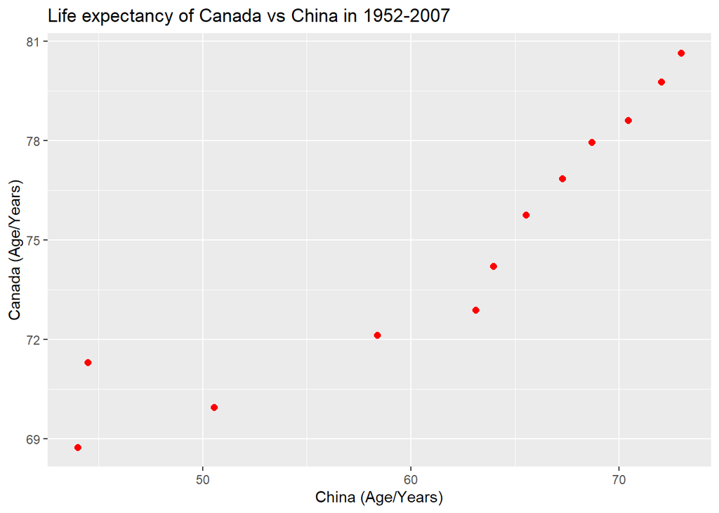

```r
LifeExp1 %>%
  ggplot (aes(x=China, y=Canada)) +
  geom_point(color = "red", size = 2) +
  labs (title = "Life expectancy of Canada vs China in 1952-2007", x = "China (Age/Years)", y = "Canada (Age/Years)")
```

## 3. Re-lengthening the wider data

```r
LifeExp1 %>%
  pivot_longer(col = -year,
              names_to = "Countries",
              values_to = "lifeExp"
               ) %>%
  DT::datatable()
```

|  | year | Countries | lifeExp |
| --- | --- | --- | --- |
| 1 | 1952 | Afghanistan | 28.801 |
| 2 | 1952 | Canada | 68.75 |
| 3 | 1952 | China | 44 |
| 4 | 1957 | Afghanistan | 30.332 |
| 5 | 1957 | Canada | 69.96 |
| 6 | 1957 | China | 50.54896 |
| 7 | 1962 | Afghanistan | 31.997 |
| 8 | 1962 | Canada | 71.3 |
| 9 | 1962 | China | 44.50136 |
| 10 | 1967 | Afghanistan | 34.02 |

[output cut: 26 more lines]

# Exercise 2: Multivariate Data Reshaping - Multivariate Option 1

## 1. Putting data in wider format

Make a tibble with one row per year, and columns for life expectancy and GDP per capita (or two other numeric variables) for two or more countries.

```r
LifeExp2 <- gapminder %>%
  select (year, lifeExp, gdpPercap, country) %>%
  filter(country == "Canada" | country == "China" | country == "Afghanistan") %>%
  pivot_wider (id_cols = c(year,country),
              names_from = "country",
              names_sep = " ",
              values_from = c(gdpPercap, lifeExp)
              )

DT::datatable(LifeExp2)
```

|  | year | gdpPercap Afghanistan | gdpPercap Canada | gdpPercap China | lifeExp Afghanistan | lifeExp Canada | lifeExp China |
| --- | --- | --- | --- | --- | --- | --- | --- |
| 1 | 1952 | 779.4453145 | 11367.16112 | 400.448611 | 28.801 | 68.75 | 44 |
| 2 | 1957 | 820.8530296 | 12489.95006 | 575.9870009 | 30.332 | 69.96 | 50.54896 |
| 3 | 1962 | 853.10071 | 13462.48555 | 487.6740183 | 31.997 | 71.3 | 44.50136 |
| 4 | 1967 | 836.1971382 | 16076.58803 | 612.7056934 | 34.02 | 72.13 | 58.38112 |
| 5 | 1972 | 739.9811058 | 18970.57086 | 676.9000921 | 36.088 | 72.88 | 63.11888 |
| 6 | 1977 | 786.11336 | 22090.88306 | 741.2374699 | 38.438 | 74.21 | 63.96736 |
| 7 | 1982 | 978.0114388 | 22898.79214 | 962.4213805 | 39.854 | 75.76 | 65.525 |
| 8 | 1987 | 852.3959448 | 26626.51503 | 1378.904018 | 40.822 | 76.86 | 67.274 |
| 9 | 1992 | 649.3413952 | 26342.88426 | 1655.784158 | 41.674 | 77.95 | 68.69 |
| 10 | 1997 | 635.341351 | 28954.92589 | 2289.234136 | 41.763 | 78.61 | 70.426 |

[output cut: 2 more lines]

## 2. Re-lengthening the data

```r
LifeExp2 %>%
  pivot_longer (cols = -year,
                names_sep = " ",
                names_to = c(".value", "country")
                  )%>%
  DT::datatable()
```

|  | year | country | gdpPercap | lifeExp |
| --- | --- | --- | --- | --- |
| 1 | 1952 | Afghanistan | 779.4453145 | 28.801 |
| 2 | 1952 | Canada | 11367.16112 | 68.75 |
| 3 | 1952 | China | 400.448611 | 44 |
| 4 | 1957 | Afghanistan | 820.8530296 | 30.332 |
| 5 | 1957 | Canada | 12489.95006 | 69.96 |
| 6 | 1957 | China | 575.9870009 | 50.54896 |
| 7 | 1962 | Afghanistan | 853.10071 | 31.997 |
| 8 | 1962 | Canada | 13462.48555 | 71.3 |
| 9 | 1962 | China | 487.6740183 | 44.50136 |
| 10 | 1967 | Afghanistan | 836.1971382 | 34.02 |

[output cut: 26 more lines]

# Exercise 3: Table Joins

**Here are two tables we are using for Joins practice**

```r
guest <- read_csv("https://raw.githubusercontent.com/STAT545-UBC/Classroom/master/data/wedding/attend.csv")
email <- read_csv("https://raw.githubusercontent.com/STAT545-UBC/Classroom/master/data/wedding/emails.csv")

DT::datatable(guest)
```

|  | party | name | meal_wedding | meal_brunch | attendance_wedding | attendance_brunch | attendance_golf |
| --- | --- | --- | --- | --- | --- | --- | --- |
| 1 | 1 | Sommer Medrano | PENDING | PENDING | PENDING | PENDING | PENDING |
| 2 | 1 | Phillip Medrano | vegetarian | Menu C | CONFIRMED | CONFIRMED | CONFIRMED |
| 3 | 1 | Blanka Medrano | chicken | Menu A | CONFIRMED | CONFIRMED | CONFIRMED |
| 4 | 1 | Emaan Medrano | PENDING | PENDING | PENDING | PENDING | PENDING |
| 5 | 2 | Blair Park | chicken | Menu C | CONFIRMED | CONFIRMED | CONFIRMED |
| 6 | 2 | Nigel Webb |  |  | CANCELLED | CANCELLED | CANCELLED |
| 7 | 3 | Sinead English | PENDING | PENDING | PENDING | PENDING | PENDING |
| 8 | 4 | Ayra Marks | vegetarian | Menu B | PENDING | PENDING | PENDING |
| 9 | 5 | Atlanta Connolly | PENDING | PENDING | PENDING | PENDING | PENDING |
| 10 | 5 | Denzel Connolly | fish | Menu B | CONFIRMED | CONFIRMED | CONFIRMED |

[output cut: 20 more lines]

```r
DT::datatable(email)
```

|  | guest | email |
| --- | --- | --- |
| 1 | Sommer Medrano, Phillip Medrano, Blanka Medrano, Emaan Medrano | sommm@gmail.com |
| 2 | Blair Park, Nigel Webb | bpark@gmail.com |
| 3 | Sinead English | singlish@hotmail.ca |
| 4 | Ayra Marks | marksa42@gmail.com |
| 5 | Jolene Welsh, Hayley Booker | jw1987@hotmail.com |
| 6 | Amayah Sanford, Erika Foley | erikaaaaaa@gmail.com |
| 7 | Ciaron Acosta | shining_ciaron@gmail.com |
| 8 | Diana Stuart | doodledianastu@gmail.com |
| 9 | Daisy-May Caldwell, Martin Caldwell, Violet Caldwell, Nazifa Caldwell, Eric Caldwell | caldwellfamily5212@gmail.com |
| 10 | Rosanna Bird, Kurtis Frost | rosy1987b@gmail.com |

[output cut: 4 more lines]

## Practice 1

**For each guest in the guestlist (guest tibble), add a column for email address, which can be found in the email tibble.**

```r
guest
```

| party | name | meal_wedding | meal_brunch | attendance_wedding | attendance_brunch | attendance_golf |
| --- | --- | --- | --- | --- | --- | --- |
| 1 | Sommer Medrano | PENDING | PENDING | PENDING | PENDING | PENDING |
| 1 | Phillip Medrano | vegetarian | Menu C | CONFIRMED | CONFIRMED | CONFIRMED |
| 1 | Blanka Medrano | chicken | Menu A | CONFIRMED | CONFIRMED | CONFIRMED |
| 1 | Emaan Medrano | PENDING | PENDING | PENDING | PENDING | PENDING |
| 2 | Blair Park | chicken | Menu C | CONFIRMED | CONFIRMED | CONFIRMED |
| 2 | Nigel Webb | NA | NA | CANCELLED | CANCELLED | CANCELLED |
| 3 | Sinead English | PENDING | PENDING | PENDING | PENDING | PENDING |
| 4 | Ayra Marks | vegetarian | Menu B | PENDING | PENDING | PENDING |
| 5 | Atlanta Connolly | PENDING | PENDING | PENDING | PENDING | PENDING |
| 5 | Denzel Connolly | fish | Menu B | CONFIRMED | CONFIRMED | CONFIRMED |

[output cut: 20 more lines]

```r
email
```

| guest | email |
| --- | --- |
| Sommer Medrano, Phillip Medrano, Blanka Medrano, Emaan Medrano | sommm@gmail.com |
| Blair Park, Nigel Webb | bpark@gmail.com |
| Sinead English | singlish@hotmail.ca |
| Ayra Marks | marksa42@gmail.com |
| Jolene Welsh, Hayley Booker | jw1987@hotmail.com |
| Amayah Sanford, Erika Foley | erikaaaaaa@gmail.com |
| Ciaron Acosta | shining_ciaron@gmail.com |
| Diana Stuart | doodledianastu@gmail.com |
| Daisy-May Caldwell, Martin Caldwell, Violet Caldwell, Nazifa Caldwell, Eric Caldwell | caldwellfamily5212@gmail.com |
| Rosanna Bird, Kurtis Frost | rosy1987b@gmail.com |

[output cut: 4 more lines]

```r
emailList <- email %>%
  separate_rows(guest, sep = ", ")

guest %>%
  left_join (emailList, by = c("name" = "guest")) %>%
  DT::datatable()
```

|  | party | name | meal_wedding | meal_brunch | attendance_wedding | attendance_brunch | attendance_golf | email |
| --- | --- | --- | --- | --- | --- | --- | --- | --- |
| 1 | 1 | Sommer Medrano | PENDING | PENDING | PENDING | PENDING | PENDING | sommm@gmail.com |
| 2 | 1 | Phillip Medrano | vegetarian | Menu C | CONFIRMED | CONFIRMED | CONFIRMED | sommm@gmail.com |
| 3 | 1 | Blanka Medrano | chicken | Menu A | CONFIRMED | CONFIRMED | CONFIRMED | sommm@gmail.com |
| 4 | 1 | Emaan Medrano | PENDING | PENDING | PENDING | PENDING | PENDING | sommm@gmail.com |
| 5 | 2 | Blair Park | chicken | Menu C | CONFIRMED | CONFIRMED | CONFIRMED | bpark@gmail.com |
| 6 | 2 | Nigel Webb |  |  | CANCELLED | CANCELLED | CANCELLED | bpark@gmail.com |
| 7 | 3 | Sinead English | PENDING | PENDING | PENDING | PENDING | PENDING | singlish@hotmail.ca |
| 8 | 4 | Ayra Marks | vegetarian | Menu B | PENDING | PENDING | PENDING | marksa42@gmail.com |
| 9 | 5 | Atlanta Connolly | PENDING | PENDING | PENDING | PENDING | PENDING |  |
| 10 | 5 | Denzel Connolly | fish | Menu B | CONFIRMED | CONFIRMED | CONFIRMED |  |

[output cut: 20 more lines]

## Practice 2

```r
emailList <- email %>%
  separate_rows(guest, sep = ", ")

guest %>%
  anti_join(emailList, by = c("name" = "guest")) %>%
  select (name) %>%
  DT::datatable()
```

|  | name |
| --- | --- |
| 1 | Atlanta Connolly |
| 2 | Denzel Connolly |
| 3 | Chanelle Shah |
| 4 | Cosmo Dunkley |
| 5 | Cai Mcdaniel |

## Practice 3

**3.3 Make a guestlist that includes everyone we have emails for (in addition to those on the original guestlist).**

```r
guest %>%
  full_join(emailList, by = c("name" = "guest")) %>%
  select (name, email) %>%
  DT::datatable()
```

|  | name | email |
| --- | --- | --- |
| 1 | Sommer Medrano | sommm@gmail.com |
| 2 | Phillip Medrano | sommm@gmail.com |
| 3 | Blanka Medrano | sommm@gmail.com |
| 4 | Emaan Medrano | sommm@gmail.com |
| 5 | Blair Park | bpark@gmail.com |
| 6 | Nigel Webb | bpark@gmail.com |
| 7 | Sinead English | singlish@hotmail.ca |
| 8 | Ayra Marks | marksa42@gmail.com |
| 9 | Atlanta Connolly |  |
| 10 | Denzel Connolly |  |

[output cut: 23 more lines]